# Drug Abuse Report

#### Religion

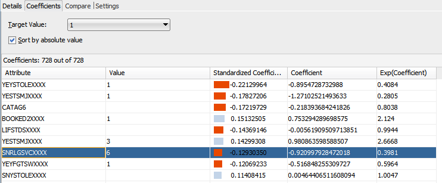

Number of religious services the respondent has attended in the past year, SNRLGSVC, was also a high confidence predictor for marijuana usage.

```
## stat_bin: binwidth defaulted to range/30. Use 'binwidth = x' to adjust this.
```

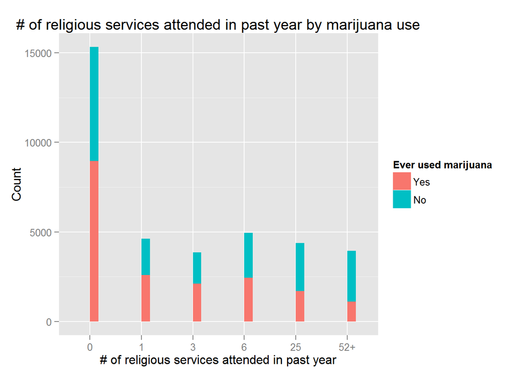

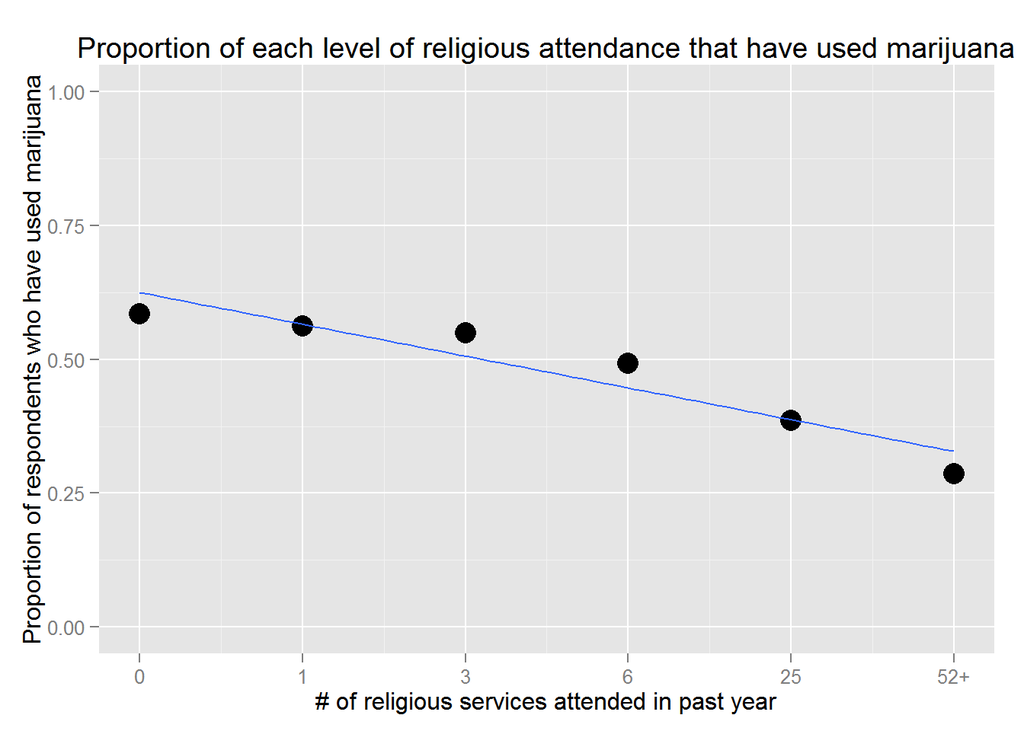

### Heroin Oxycontin

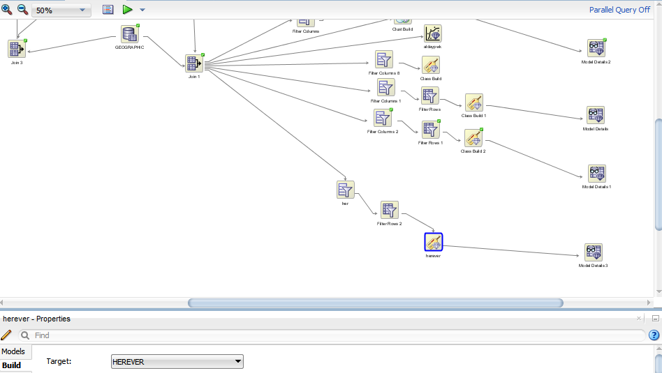

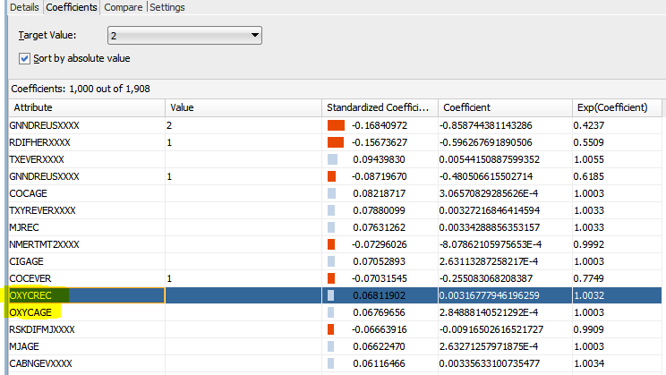

An alarming connection was also discovered between use of the narcotic, opioid (opiate-like) painkiller Oxycontin that is often prescribed after surgery and heroin use. When using classification algorithms to predict heroin usage, oxycontin related variables showed up near the top with the highest confidence variables.

```
## stat_bin: binwidth defaulted to range/30. Use 'binwidth = x' to adjust this.
```

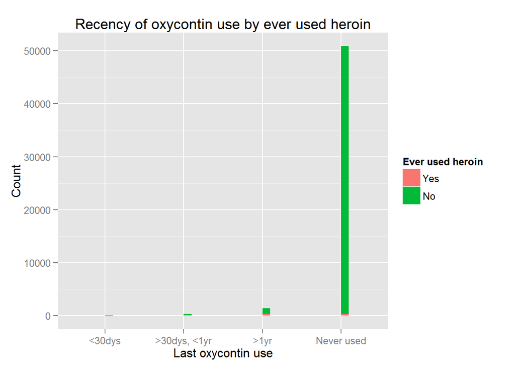

First bargraph only included for scale.

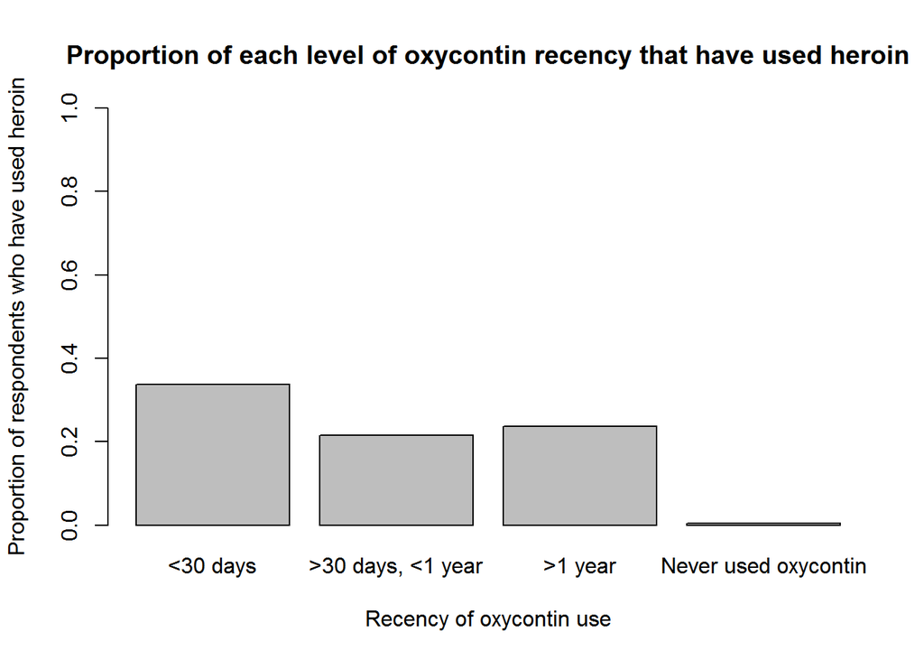

As you can see, heroin use among people who have used Oxycontin is much higher than heroin use among those who have never used oxycontin with a difference in proportions of .332 between those who have used oxycontin in the last 30 days and those who have never used oxycontin. This is perhaps largely due to heroin users who choose to use oxycontin due to its similarity to heroin and due to the fact that it is more common in society and exists in many places legally. Another factor though is the correlation working the other way where surgery patients become dependent on their oxycontin prescription and then choose to buy and use heroin illegally after the prescription expires to get the same experience.